# Прогнозирование заказов такси

### 3.3. Подготовка валидации.

```python
'''
def time_series_custom(splits, data):
    custom_cv = []
    test_index = (9 * (data.shape[0]//10))
    for i in range(splits-1, -1, -1):
        range_1 = range(test_index // splits * i, test_index)
        range_2 = range(test_index, data.shape[0])
        print((range_1, range_2))
        custom_cv.append((
            list(range_1),
            list(range_2)
        ))
    return custom_cv

ts_cv = time_series_custom(3, targ_train)
'''

ts_cv = TimeSeriesSplit(3, test_size=round(targ_train.shape[0]/10))
split_keys_list = [f'split{i}_test_score' for i in range(ts_cv.n_splits)]
```

```python
def cross_val_eval(model):
    return -cross_val_score(model, feat_train, targ_train, cv=ts_cv, scoring='neg_root_mean_squared_error')
```

**Выводы**

Создана функция для упрощения оценки модели.

```python
ts_cv_sklearn = TimeSeriesSplit(3, test_size=targ_train.shape[0]//10)

list(ts_cv_sklearn.split(targ_train))[-1][1][[0,-1]]
```

```
array([3425, 3804])
```

```python
list(ts_cv_sklearn.split(targ_train))[-2][1][[0,-1]]
```

```
array([3045, 3424])
```

```python
list(ts_cv_sklearn.split(targ_train))[-3][1][[0,-1]]
```

```
array([2665, 3044])
```

### 3.4. Dummy

```python
class DummyPrevious(BaseEstimator, RegressorMixin):
    def fit(self, X, y):
        return self
    def predict(self, X, return_std=False):
        try:
            y_pred = X['lag_1']
        except:
            y_pred = dfhf.num_orders.shift()[X.index]
        return y_pred
    def score(self, X, y, sample_weight=None):
        try:
            y_pred = X['lag_1']
        except:
            y_pred = dfhf.num_orders.shift()[X.index]
        return r2_score(y, y_pred)

dummy_prev=DummyPrevious()
```

```python
dummy_mean = DummyRegressor(strategy='mean')
dummy_median = DummyRegressor(strategy='median')
```

```python
cross_val_eval(dummy_prev)
```

```
array([38.3369411 , 44.84388123, 47.27495164])
```

```python
cross_val_eval(dummy_mean)
```

```
array([40.13807737, 49.7971101 , 57.38379259])
```

```python
cross_val_eval(dummy_median)
```

```
array([41.67512195, 50.72339852, 59.17307354])
```

**Выводы**

Создан класс для модели предсказывающей предыдущее значение для проверки вменяемости.

Предыдущие значения дают наилучший RMSE, будем считать это значение основой для сравнения. Последнее предсказание чуть ниже требуемого заказчиком на тестовой выборке. Высокие значения RMSE для среднего и медианы скорее всего объясняются нестационарностью ряда. Особенно видно в конце, где значения начинают резко расти, а качество предсказания падать как следствие. Учитывая, что тренд на возрастание сохраняется, и даже усиливается, наиболее интересным является значение на последней выборки кросс валидации.

### 3.5. LGBM

```python
lgbm = LGBMRegressor(random_state=RANDOM, verbose=-1, n_jobs=4)
```

```python
lgbm.get_params()
```

```
{'boosting_type': 'gbdt',
 'class_weight': None,
 'colsample_bytree': 1.0,
 'importance_type': 'split',
 'learning_rate': 0.1,
 'max_depth': -1,
 'min_child_samples': 20,
 'min_child_weight': 0.001,
 'min_split_gain': 0.0,
 'n_estimators': 100,
 'n_jobs': 4,
 'num_leaves': 31,
 'objective': None,
 'random_state': 0,
 'reg_alpha': 0.0,
 'reg_lambda': 0.0,
 'subsample': 1.0,
 'subsample_for_bin': 200000,
 'subsample_freq': 0,
 'verbose': -1}
```

```python
cross_val_eval(lgbm)
```

```
array([21.85058927, 26.78659767, 28.9817298 ])
```

```python
parameter_grid_lgbm = {
    'max_depth': [-1, 2, 4, 8],
    'num_leaves': [31, 20, 50, 100],
    'min_child_samples': [20, 30, 50],
    'subsample_for_bin': [5, 10, 200000]
}

gs_cv_lgbm = GridSearchCV(lgbm, parameter_grid_lgbm, cv=ts_cv,
                                scoring='neg_root_mean_squared_error')
gs_cv_lgbm.fit(feat_train, targ_train)
-gs_cv_lgbm.best_score_
```

```
25.351949924772544
```

```python
print('cross val best')
[-gs_cv_lgbm.cv_results_.get(key)[gs_cv_lgbm.best_index_] for key in split_keys_list]
```

```
cross val best
```

```
[21.287646542828828, 26.213509618712784, 28.554693612776028]
```

```python
gs_cv_lgbm.best_params_
```

```
{'max_depth': 4,
 'min_child_samples': 50,
 'num_leaves': 31,
 'subsample_for_bin': 200000}
```

**Выводы**

### 3.6. LinearRegression

```python
lin_reg = LinearRegression()
```

```python
lin_reg_cv = cross_val_eval(lin_reg)
lin_reg_cv
```

```
array([22.25226574, 25.87439517, 28.06264708])
```

```python
lin_reg_cv.mean()
```

```
25.396435998137832
```

**Выводы**

Линейная регрессия работает показала себя чуть хуже LGBM в среднем, но несколько лучше на наибольшей выборке. Учитывая тренд на рост, можно считать её в целом лучше LGBM.

### 3.7. RandomForest

```python
ran_fst = RandomForestRegressor(random_state=RANDOM, n_jobs=4)
```

```python
cross_val_eval(ran_fst)
```

```
array([20.93704354, 27.21982207, 29.69107015])
```

```python
ran_fst.get_params()
```

```
{'bootstrap': True,
 'ccp_alpha': 0.0,
 'criterion': 'squared_error',
 'max_depth': None,
 'max_features': 1.0,
 'max_leaf_nodes': None,
 'max_samples': None,
 'min_impurity_decrease': 0.0,
 'min_samples_leaf': 1,
 'min_samples_split': 2,
 'min_weight_fraction_leaf': 0.0,
 'n_estimators': 100,
 'n_jobs': 4,
 'oob_score': False,
 'random_state': 0,
 'verbose': 0,
 'warm_start': False}
```

```python
parameter_grid_ran_fst = {
    'max_depth': [2, 4, 6, 16],
    'n_estimators': [75, 100, 125],
    'criterion': ['squared_error', 'absolute_error'],
    'min_samples_leaf': [3, 5, 7, 9]
}
```

```python
rscv_ran_fst = RandomizedSearchCV(ran_fst, parameter_grid_ran_fst, cv=ts_cv, n_iter=5,
                                  scoring='neg_root_mean_squared_error' , random_state=RANDOM)
rscv_ran_fst.fit(feat_train, targ_train)
-rscv_ran_fst.best_score_
```

```
26.38647078898781
```

```python
rscv_ran_fst.best_params_
```

```
{'n_estimators': 125,
 'min_samples_leaf': 3,
 'max_depth': 6,
 'criterion': 'squared_error'}
```

```python
print('cross val best')
[-rscv_ran_fst.cv_results_.get(key)[rscv_ran_fst.best_index_] for key in split_keys_list]
```

```
cross val best
```

```
[21.10039870440032, 27.412686478357106, 30.64632718420601]
```

**Выводы**

Случайный лес показывает результаты хуже линейной регрессии и бустинга. Перебор гиперпараметров не улучшил модель, ввиду выбранной сетки параметров. Для данной конфигурации признаков лес работает очень медленно, что затрудняет перебор.

## 4. Тестирование

### 4.1. LinReg лучший

```python
lin_reg.fit(feat_train, targ_train)
pred_test = lin_reg.predict(feat_test)
```

```python
mean_squared_error(targ_test, pred_test, squared=False)
```

```
34.69294584889651
```

```python
r2_score(targ_test, pred_test)
```

```
0.6488971515100632
```

```python
mean_absolute_error(targ_test, pred_test)
```

```
25.69705634690781
```

```python
targ_test.mean()
```

```
139.55656108597285
```

```python
mean_absolute_error(targ_test, pred_test) / targ_test.mean()
```

```
0.184133631173939
```

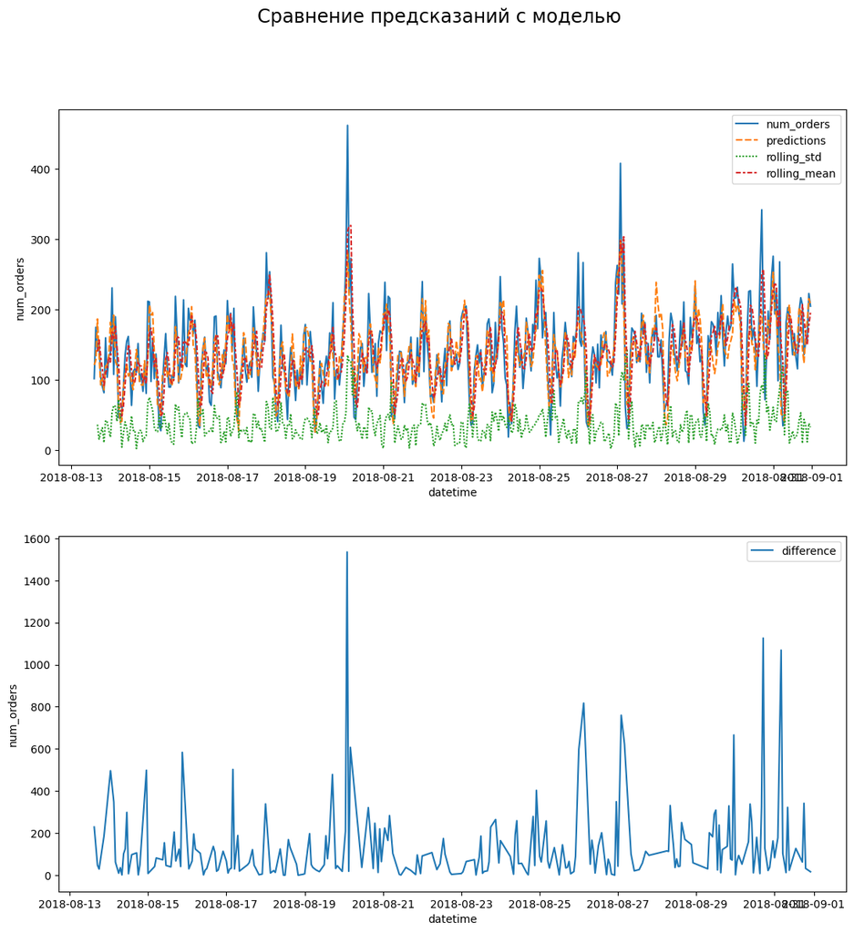

```python
demonstration = pd.concat([targ_test, pd.Series(pred_test, name='predictions', index=targ_test.index)], axis=1)
demo_2 = pd.DataFrame()
demo_2['difference'] = (demonstration.num_orders - demonstration.predictions)**2**.5
demonstration['rolling_std'] = demonstration.num_orders.rolling(3, center=True, closed='left').std()
demonstration['rolling_mean'] = demonstration.num_orders.rolling(3, center=True, closed='left').mean()

fig, ax = plt.subplots(2, 1, figsize=(13, 13))
plt.suptitle('Сравнение предсказаний с моделью', size='xx-large');
sns.lineplot(ax=ax[0], data=demonstration)
ax[0].set_ylabel('num_orders');

sns.lineplot(ax=ax[1], data=demo_2)
plt.ylabel('num_orders');
```

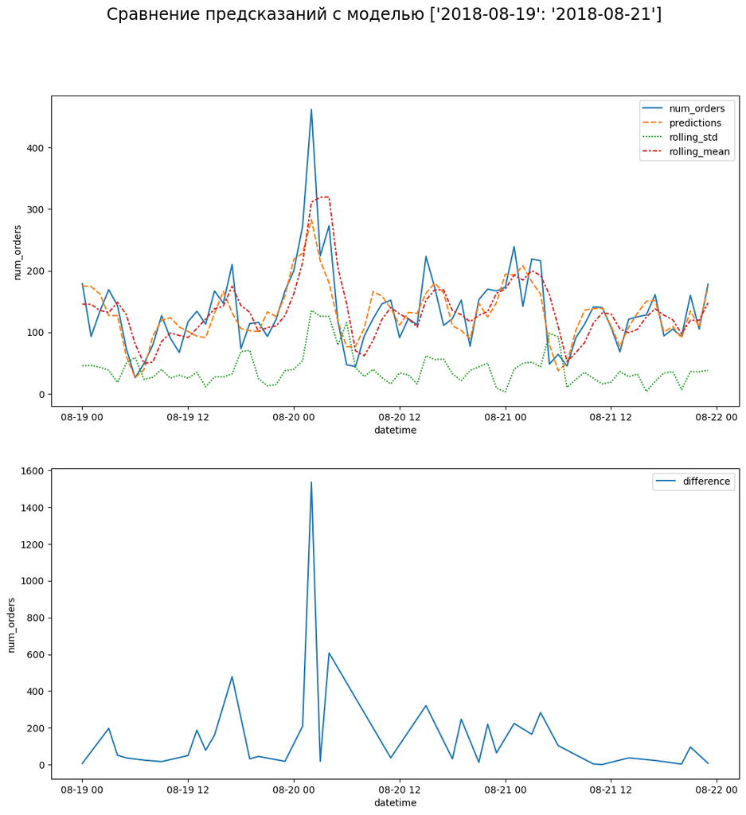

```python
fig, ax = plt.subplots(2, 1, figsize=(13, 13))
plt.suptitle("Сравнение предсказаний с моделью ['2018-08-19': '2018-08-21']", size='xx-large');
sns.lineplot(ax=ax[0], data=demonstration['2018-08-19': '2018-08-21'])
ax[0].set_ylabel('num_orders');

sns.lineplot(ax=ax[1], data=demo_2['2018-08-19': '2018-08-21'])
plt.ylabel('num_orders');
```

**Выводы**

Показатель RMSE ниже требуемого заказчиком. R2 показывает, что модель превосходит среднее. Сравнивая MAE со средними значением можно говорить о том что ошибка около 18%, это весьма высокое значение, но в целом показывает что модель весьма полезна. В реальных условиях, возможно можно значительно улучшить собрав дополнительную информацию об использовании такси в городе заказчика, например погода, пробки, тарифы. условия конкурентов.

Сравнивая предсказания с реальными значениями тестовой выборки, можно увидеть, что модель затрудняется точно предсказывать значения, в периоды где имеется высокое отклонение.

### 4.2. Вменяемость - DummyPrevious

```python
mean_squared_error(targ_test, dummy_prev.predict(feat_test), squared=False)
```

```
58.856486242815066
```

**Выводы**

В отличие от обучающей выборки, показатели на тестовой у предсказания по предыдущему значительно выше требуемых, как следствие можно говорить о том что обучение модели проведено не зря.

## 5. Заключение

Проект позволяет увидеть, как разумное использование информации о предыдущих значения ЦП на временном ряду, даёт возможность предсказывать будущие значения, даже в отсутствии других признаков. Это особенно удобно в условиях когда нужно предсказать результат на ближайшее время, например час/день, что позволяет использовать данные практически в реальном времени и не требует построения долгосрочной стратегии на основании предсказаний.